# POLI 110

November 5, 2026

## Testing Causal Claims

### **1. Fundamental Problem of Causal Inference**

- independent/dependent variables
- solutions

### **2. Correlation**

- what is it?
- problems with correlation
- Random association

## An Example

[figure not shown]

## Social Media and Polarization:

**Claim:** “Reliance on social media for political information increases political polarization.”

- What is the counterfactual claim?
- What potential outcomes does it imply?

## Independent/Dependent Variables

**Independent variable:**

The variable capturing the alleged **cause** in a causal claim.

- often denoted as \(X\)

**Dependent variable:**

The variable capturing the alleged **outcome** (what is affected) in a causal claim.

- often denoted as \(Y\)

**Dependent Variable:** Polarization

[figure not shown]

**Independent Variable:** News from Social Media

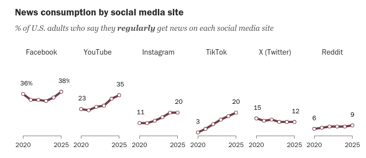

## Evidence for Causal Claims

Which potential outcome does this evidence give us? (Board)

Can this evidence tell us whether social media caused polarization?

## Evidence for Causal Claims

**Severity…**

Even if social media use **didn’t** increase polarization…

Could we see this evidence (US has both social media use and polarization)?

- If we want to find the **cause** of polarization, starting from case of **high polarization** like the US is **selection on dependent variable**

## Selection on the Dependent Variable

when attempting to provide evidence for causal claims, **selectively** observing cases based on the **outcome** they experience

- two problems \(\to\) absence of weak severity

## Selection on the Dependent Variable

**Problem 1**: creates opportunity for “Texas Sharpshooter Fallacy”

[figure not shown]

“Fence” is case with outcome “high polarization”; “bullet holes” are attributes of that case

- can point to *any* attribute of the US and highlight as the “cause” (paint a bulls-eye)

[figure not shown]

## Selection on the Dependent Variable

**Problem 2**: Causality is counterfactual. Outcome should be different when **independent variable** changes. Selecting on dependent variable: never observe outcome under different exposure to the “cause”.

- **outcome** (polarization) could have occurred **without** the alleged “cause” (social media). Without observing the counterfactual, we can’t rule this out.

## Evidence for Causal Claims

Based on what we see in 2024…

\(\color{red}{\text{Polarization}_{USA}(\text{Social Media})} = \ \mathbf{????}\):

- How could we know what this is?
- We can **never know** what polarization would have been, absent social media usage

## What is the problem here?

### **Fundamental Problem of Causal Inference**

1. For the US, where people use social media: we can **only** observe the potential outcome of \(\text{Polarization}_{USA}\) for where the value of \(\text{Social Media} = High\): what **actually** happened.
2. We can **never observe** the other, **counterfactual**, potential outcomes of \(\color{red}{\text{Polarization}_{USA}}\) where \(\color{red}{\text{Social Media} = Low}\), because that was not what happened.
3. We can never **empirically** observe, for the US, whether \(\text{Social Media}\) usage caused \(\uparrow \text{Polarization}\).

## What is the problem here?

### **Fundamental Problem of Causal Inference**

1. By definition, \(X\) causes \(Y\) if the potential outcomes of \(Y_i(X)\) were different if we changed \(X\) for the exact same case.
2. For a specific case, we can **only** observe the potential outcome of \(Y\) for the value of \(X\) it **actually takes**.
3. We **never observe** the **counterfactual** potential outcomes of \(Y\) for different possible values of \(X\) that the case did not experience.
4. We can never **empirically** observe, for a specific case, whether \(X\) causes \(Y\).

[figure not shown]

## You might be asking…

**I thought evidence for empirical claims based on *observing the world*?!**

**If we can never see the counterfactual… does this mean that *all* evidence for causal claims fails *weak severity*?**

**Are there “solutions” to this fundamental problem?**

## Solving the FPCI?

If getting news from social media increases polarization, it must true that:

\(\color{red}{\mathrm{Polarization}_{USA}(\mathrm{Higher \ Social \ Media})} >\) \(\mathrm{Polarization}_{USA}(\mathrm{High \ Social \ Media}) >\) \(\color{red}{\mathrm{Polarization}_{USA}(\mathrm{Low \ Social \ Media})}\)

In order to provide evidence for causal claims, we need to find ways around the FPCI:

- We need to find something we **can see** that can **stand in** for the missing **counterfactual**

## Social Media and Polarization

| \(\mathrm{Country}_i\) | \(\mathrm{Social \ Media}_i\) | \(\mathrm{Polar.}_i(\mathrm{Low \ S.M.})\) | \(\mathrm{Polar.}_i(\mathrm{High \ S.M.})\) |
| --- | --- | --- | --- |
| USA | **High** | \(\color{red}{\mathrm{Polar.}_{USA}(\mathrm{Low \ S.M.}) = ?}\) | \(\mathrm{Polar.}_{USA}(\mathrm{High \ S.M.})\) |

How could we observe “\(\color{red}{?}\)”, the unknown counterfactual?

- We could to find **another country** where there **was lower social media use**

## Social Media and Polarization

We **cannot observe**: \(\color{red}{\mathrm{Polar.}_{USA}(\mathrm{Low \ S. M.})}\)

But we **can** observe, e.g.: \(\mathrm{Polar.}_{Germany}(\mathrm{Low \ S. M.})\)

| \(\mathrm{Country}_i\) | \(\mathrm{Social \ Media}_i\) | \(\mathrm{Polar.}_i(\mathrm{Low \ S.M.})\) | \(\mathrm{Polar.}_i(\mathrm{High \ S.M.})\) |
| --- | --- | --- | --- |
| USA | **High** | \(\color{red}{\mathrm{Polar.}_{USA}(\mathrm{Low \ S.M.})= ?}\) | \(\mathrm{Polar.}_{USA}(\mathrm{High \ S.M.})\) |
|  |  | \(\mathbf{\Uparrow}\) |  |
| Germany | **Low** | \(\mathrm{Polar.}_{Germany}(\mathrm{Low \ S.M.})\) | \(\color{red}{\mathrm{Polar.}_{Germany}(\mathrm{High \ S.M.})}\) |

If we **assume**:

\(\mathrm{Polar.}_{Germany}(\mathrm{Low \ S.M.})\) \(=\) \(\color{red}{\mathrm{Polar.}_{USA}(\mathrm{Low \ S.M.})}\)

Then, we can **empirically** test our causal claim

plugging in factual \(Germany\) for the counterfactual \(USA\)

| \(\mathrm{Country}_i\) | \(\mathrm{Social \ Media}_i\) | \(\mathrm{Polar.}_i(\mathrm{Low \ S.M.})\) | \(\mathrm{Polar.}_i(\mathrm{High \ S.M.})\) |
| --- | --- | --- | --- |
| USA | **High** | \(\mathrm{Polar.}_{Germany}(\mathrm{Low \ S.M.})\) | \(\mathrm{Polar.}_{USA}(\mathrm{High \ S.M.})\) |
|  |  | \(\mathbf{\Uparrow}\) |  |
| Germany | **Low** | \(\mathrm{Polar.}_{Germany}(\mathrm{Low \ S.M.})\) | \(\color{red}{\mathrm{Polar.}_{Germany}(\mathrm{High \ S.M.})}\) |

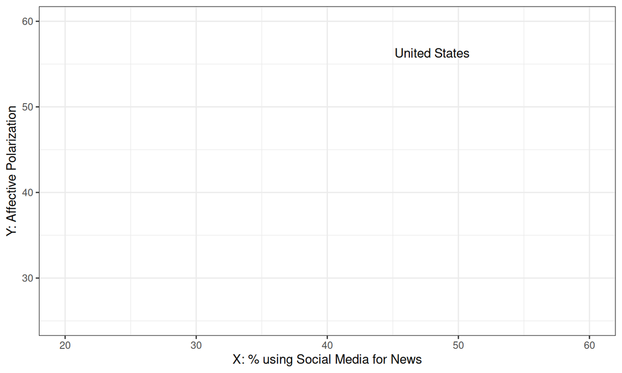

48% of Americans report using social media for news. \(\mathrm{Polarization}_{USA}(\mathrm{Social \ Media \ News =48\% }) = 56\)

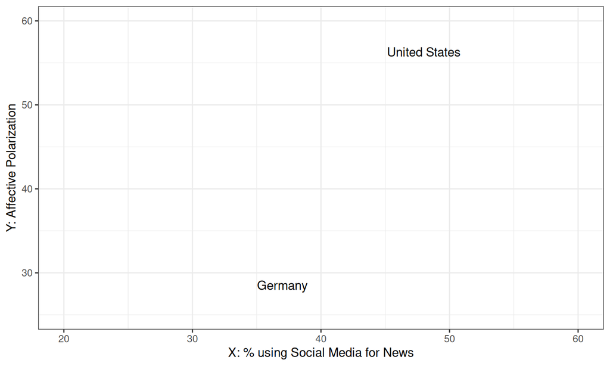

37% of Germans report using social media for news. \(\mathrm{Polarization}_{Germany}(\mathrm{Social \ Media \ News =37\% }) = 29\)

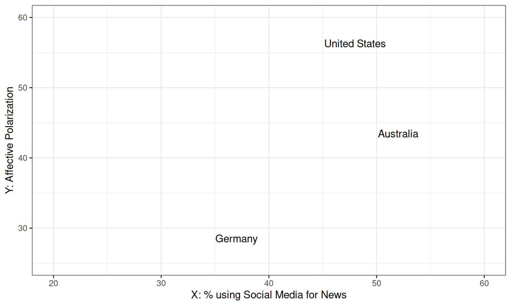

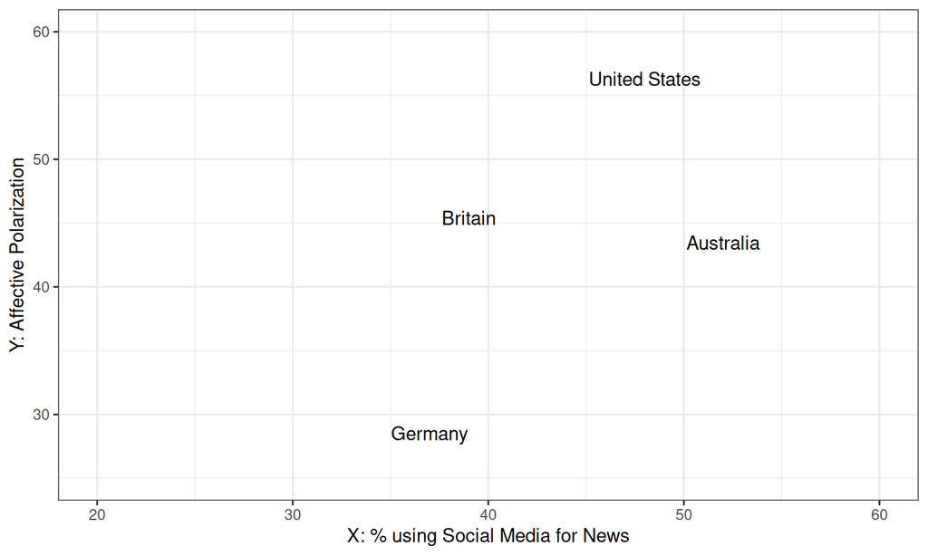

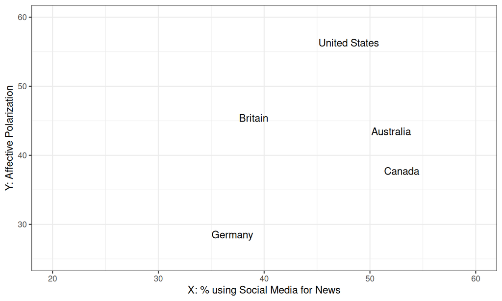

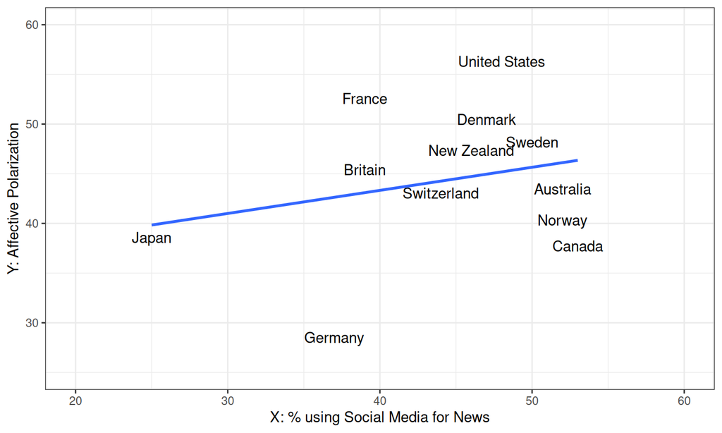

## Solving the FPCI

Every solution to the FPCI involves:

1. Comparing the **observed** values of outcome \(Y\) in cases that **factually** have different values of cause \(X\)
2. **Assuming** that **factual** (observed) potential outcomes from one case as *equivalent to* **counterfactual** (unobserved) potential outcomes of another case.
- The **observed** patterns of the association between the independent variable \(X\) and dependent variable \(Y\) we call **correlations**

## **Correlation**

**Correlation** is the association/relationship between the **observed**/**factual** values of \(X\) (the independent variable) and \(Y\) (the dependent variable)

- loosely: describes the **observed relationship** between \(X\) and \(Y\).
- formally: mathematical definitions for specific kinds of associations.

## **Correlation**

**All empirical evidence for causal claims** relies on **correlation** between the independent and dependent variables.

But, you’ve all heard this:

[figure not shown]

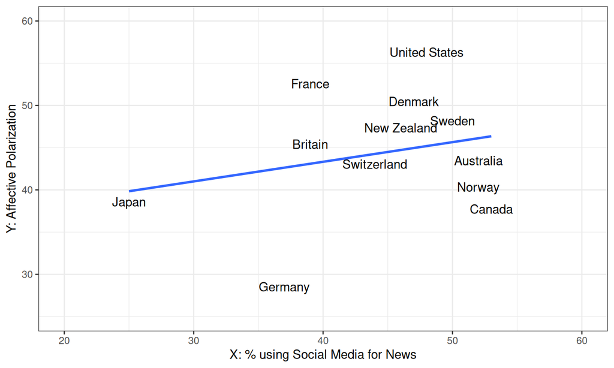

- Think about how we filled in the \(\color{red}{\text{counterfactuals}}\) for the US: could anything go wrong?

## Correlation

## **Correlation**

Many different ways of assessing correlation, but shared attributes:

- correlations have a **direction**:
  - positive: \(X\uparrow\), \(Y\uparrow\)
  - negative: \(X\uparrow\), \(Y\downarrow\)
- correlations have **strength**:
  - **strong**: \(X\) and \(Y\) almost **always** move together
  - **weak**: \(X\) and \(Y\) do not move together very much

Stronger

[figure not shown]

Weaker

## **Correlation**

Many different ways of assessing correlation, but shared attributes:

- correlations have a **direction**:
  - positive: \(X\uparrow\), \(Y\uparrow\)
  - negative: \(X\uparrow\), \(Y\downarrow\)
- correlations have **strength**:
  - **strong**: \(X\) and \(Y\) almost **always** move together
  - **weak**: \(X\) and \(Y\) do not move together very much
- correlations have a **magnitude**:
  - *how much* \(Y\) changes with \(X\).

## **Correlation**

Many ways of examining correlations:

- scatterplots (point for each case on an x-y coordinates)
- bar plots (average Y for different values of X)
- trends (how do Y and X move together over time)
- tables of coefficients

Scatterplot

Bar plot

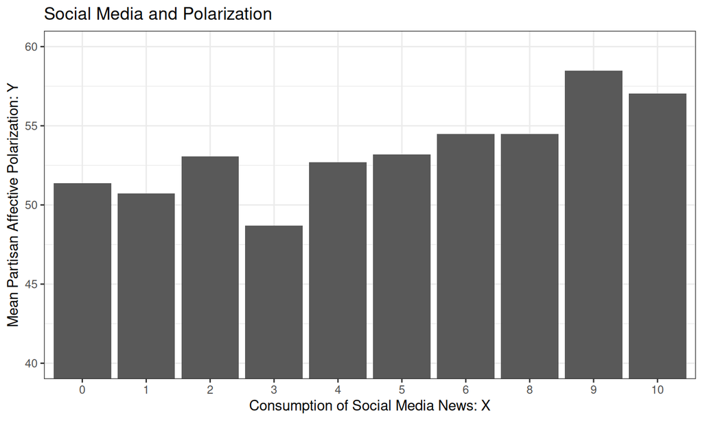

Individual data on social media use and affective polarization from ANES 2024

Trend lines

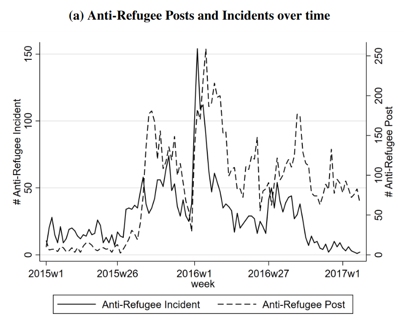

## **Correlation**

### Formally…

common **mathematical** definition: correlation is the degree of **linear** association between \(X\) and \(Y\)

- Takes values between \(-1\) and \(1\)
- Values close to \(1\) or \(-1\) suggest **strong** degree of *linear* association
- Values close to \(0\) suggest **weak** degree of *linear* association
- Value of correlation does **not** tell us **how much** \(Y\) changes with \(X\) (no magnitude)

## **Correlation**

### What is it?

**negative correlation**: (\(< 0\)) values of \(X\) and \(Y\) move in opposite direction:

- higher values of \(X\) appear with lower values of \(Y\)
- lower values of \(X\) appear with higher values of \(Y\)

**positive correlation**: (\(> 0\)) values of \(X\) and \(Y\) move in same direction:

- higher values of \(X\) appear with higher values of \(Y\)
- lower values of \(X\) appear with lower values of \(Y\)

## **Correlation**

[figure not shown]

## **Correlation**

- It is possible to see **perfect correlation** but small (magnitude) change in \(Y\) across \(X\)
- It is possible to see **weak correlation** but large (magnitude) change in \(Y\) across \(X\)
- It is possible to see **perfect nonlinear relationship** between \(X\) and \(Y\) with \(0\) correlation

## **Correlation**

**weak correlation**: values for \(X\) and \(Y\) do not cluster along line

**strong correlation**: values for \(X\) and \(Y\) cluster strongly along a line

**strength of correlation** does not determine the **slope** of line describing \(X,Y\) relationship

**magnitude**: this is the **slope** of the line describing the \(X,Y\) relationship. The larger the effect, the steeper the slope

Correlation: \(0.25\), Magnitude: \(0.23\). Does this correlation prove using social media for news **causes** polarization? Why or why not?

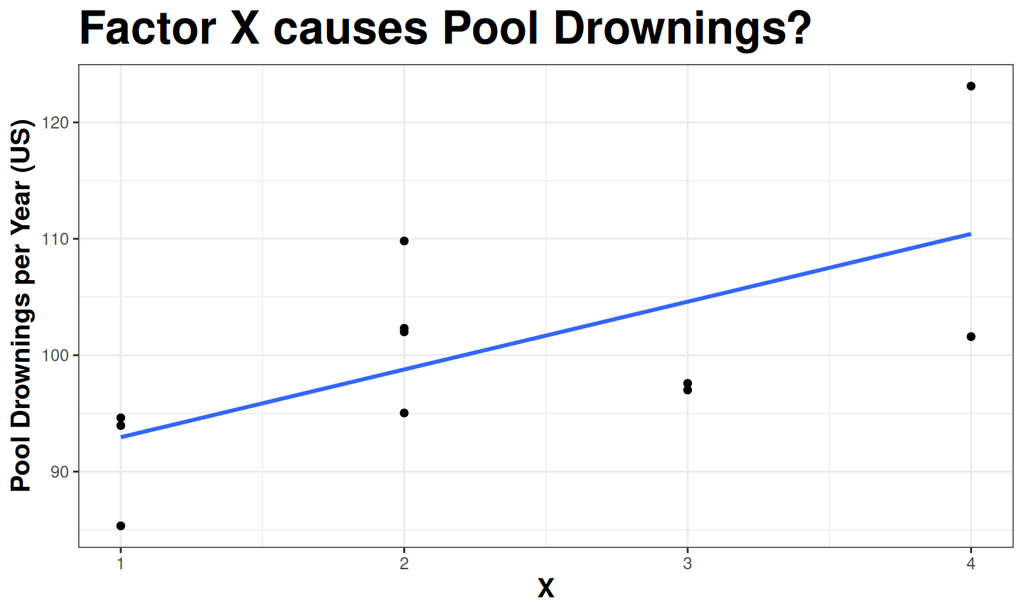

Correlation: 0.67, Magnitude: 5.82. Does this correlation prove that X **caused** drownings? Why or why not?

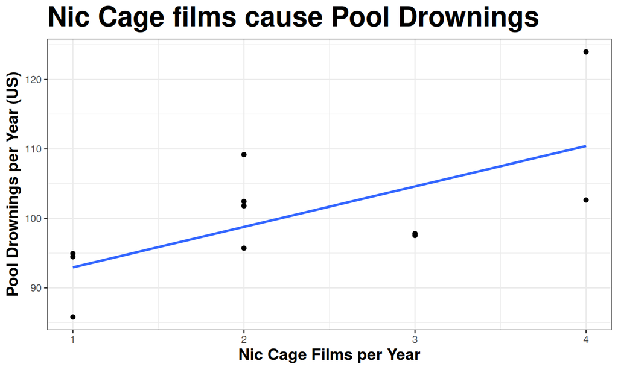

Correlation: 0.67, Magnitude: 5.82. Does this correlation prove that Nic Cage films **caused** drownings? Why or why not?

## Correlation

### **Two types of problems**

- **random association**: correlations between \(X\) and \(Y\) occur **by chance** and do not reflect *any* systematic relationship between \(X\) and \(Y\). (In the extreme, absolutely no relationship between \(X\) and \(Y\))
- **bias** (spurious correlation, **confounding**): \(X\) and \(Y\) are correlated but the correlation does not result from **causal** relationship between those variables

Avoiding these problems involves making **assumptions**: what are those assumptions? how plausible are they?

## Random Association

## Correlation: Random association

[video not shown]

## Correlation: Random association

Arbitrary processes can make seemingly-strong patterns.

If you look long enough at pure chaos, you might find a strong correlation

- It could have happened by chance!
- So an observed correlation might not mean **any** relationship (e.g. Nic Cage)

[Arbitary Correlations](http://www.tylervigen.com/spurious-correlations)

## Random association: Statistics

To see that random patterns can emerge, I use random number generators to

- **randomly** pick \(5\) values of \(X\) out of a “hat”
- **randomly** pick \(5\) values of \(Y\) out of a different “hat”

We can imagine these are the observed \(X\) and \(Y\) for \(5\) cases.

## Random association: Statistics

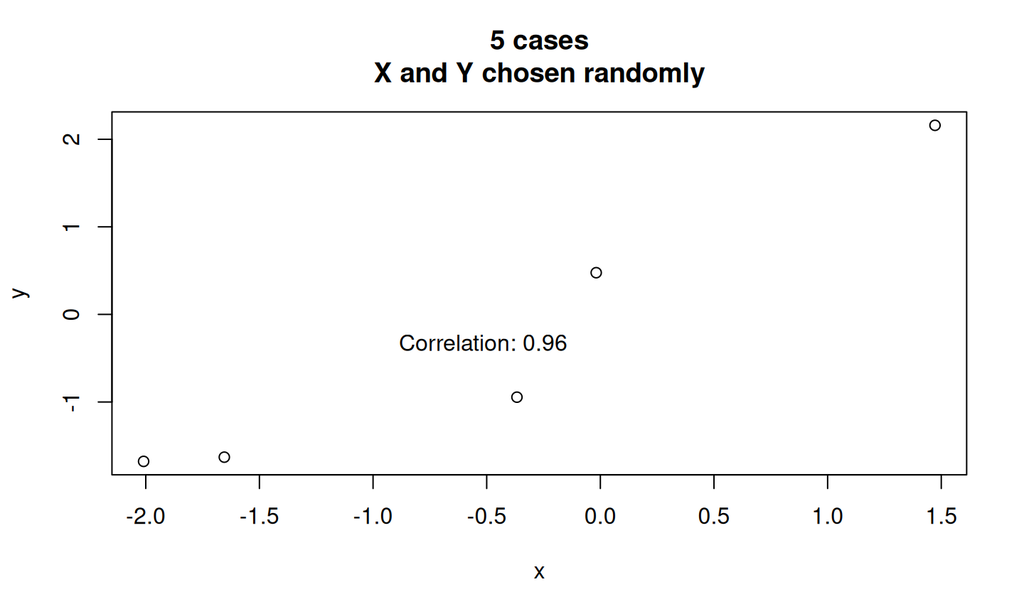

## Random association: Statistics

Could we find a strong correlation between \(X\) and \(Y\) (even if \(X\) and \(Y\) totally unrelated)?

- if it is easy, then evidence fails weak severity requirement
- if it is difficult, then it passes

## Random association: Statistics

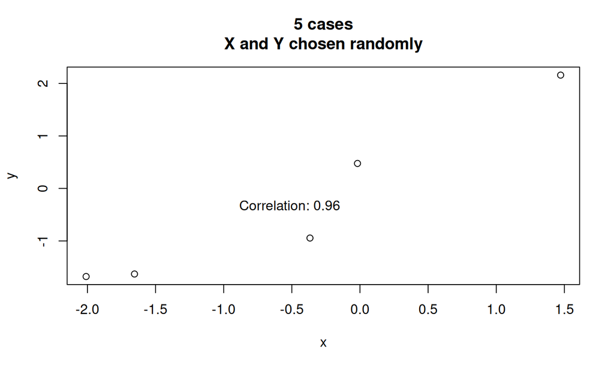

\(\#\) Tries to get correlation \(> 0.9\): 225

## Random association

What do we do about this problem?

- We can **never rule out** a chance correlation
- We *can* figure out **how likely** correlation occurred by chance.
- If chance correlation is very unlikely, then we set aside this concern (or indicate the “false positive rate” for this analysis)

## Random association: Statistics

### How?

1. Compute correlation of \(X\) and \(Y\)
2. How **strong** is the correlation?
   - Patterns that are **stronger** are **less likely** to happen by chance
3. How many **cases** do we have?
   - Patterns with **many cases** are **less likely** to happen by chance
4. Assign a probability that observed correlation would have happened by chance, **assuming claim is wrong (no real correlation)**

## Random association: Statistics

This procedure works…

### **Assuming**…

1. we **correctly** describe the chance processes (save this for a stats class)
2. we don’t misuse our statistical tests

## Random association: Statistics

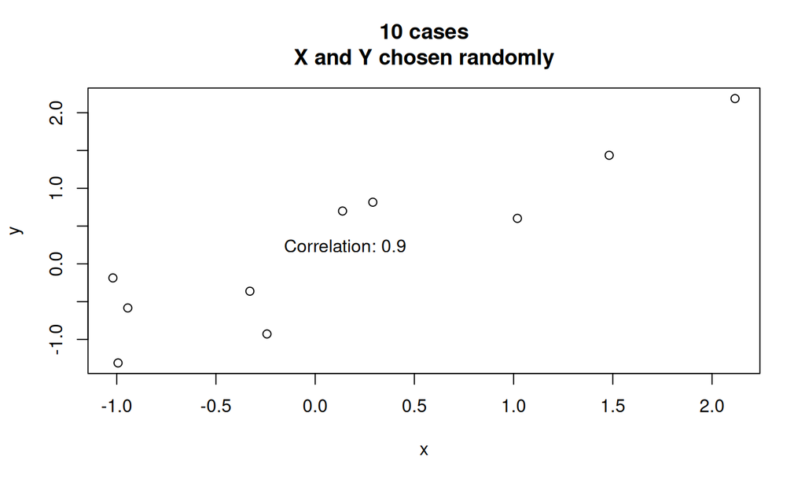

Tries to get correlation \(> 0.9\): 8282

## Random association: Statistics

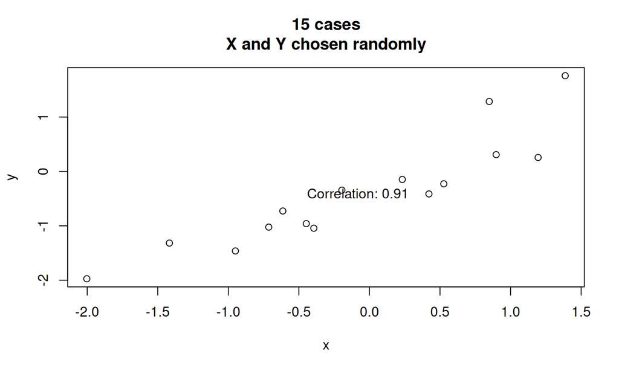

Tries to get correlation \(> 0.9\): 157692

## Random association: Statistics

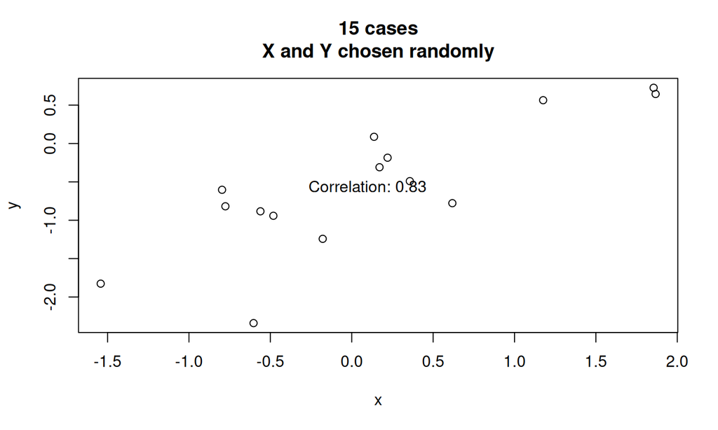

Tries to get correlation \(> 0.45\): 7

## Random association: Statistics

**statistical significance**:

> An indication of **how likely** it is that correlation we observe could have happened purely by chance.

> **higher** degree of statistical significance indicates correlation is **unlikely** to have happened by chance. (unlikely to observe evidence for the claim if claim is false)

## Random association: Statistics

\(p\) **value**:

- probability of observing this correlation, **assuming** truth is a \(0\) correlation between \(X\) and \(Y\).
- value between \(0\) and \(1\).
- **Lower** \(p\)-values indicate **greater** statistical significance

\(p < 0.05\) often used as threshold for “significant” result.

- but it is not a magic number
- we observe \(p < 0.05\) by chance (\(\frac{1}{20}\)th of the time)
- even if significant, **magnitude** of effect may be small

## Random association: Statistics

\(p\) **value**:

Advertised promise about weak severity:

if we use this correlation as evidence in support of a claim, what is probability of accepting the claim **in error** (due to **random association**)?

- only works if we don’t abuse the tests

## Significant?

[figure not shown]

## Significant?

[figure not shown]

## Significant?

[figure not shown]

## What else do you want to know?

[figure not shown]

## Same interpretation?

[figure not shown]

## Same interpretation?

[figure not shown]

## Random association: Statistics

\(p\) **value**:

Be wary of “\(p\)-hacking”/“snooping”

- \(p\) values become meaningless if we look at many correlations, then only report the ones that are “significant”.

### Why?

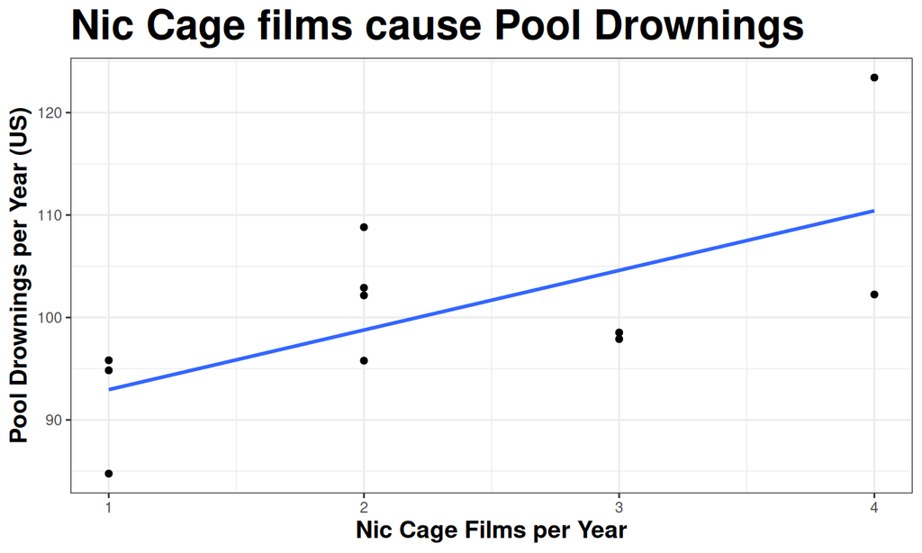

Correlation: 0.67, \(p \le\) 0.025: 1 in 40 chance is easy to find when you look at 25 thousand possible correlations.

1. Correlations can appear by chance
2. We can assess **probability** of observing correlation by chance if we know:
   - **strength** of correlation (close to \(1,-1\))
   - **size** of the sample (\(N\))
   - the **chance process** at work
3. \(p\)-values:
   - Obtained using mathematical formulae
   - Given same \(N\), stronger correlation has lower \(p\)
   - Given same strength, correlation with more \(N\) has lower \(p\)

## Random assocation: Recap

| Statistical Significance | \(p\)-value | By Chance? | Why? | “Real”? |
| --- | --- | --- | --- | --- |
| Low | High \((p > 0.05)\) | Likely | small \(N\) weak correlation | Probably **not** |
| High | Low \((p < 0.05)\) | Unlikely | large \(N\) strong correlation | Possibly |

## Conclusion

Correlation: 0.25, \(p \le\) 0.428

Does social media used **cause** polarization?

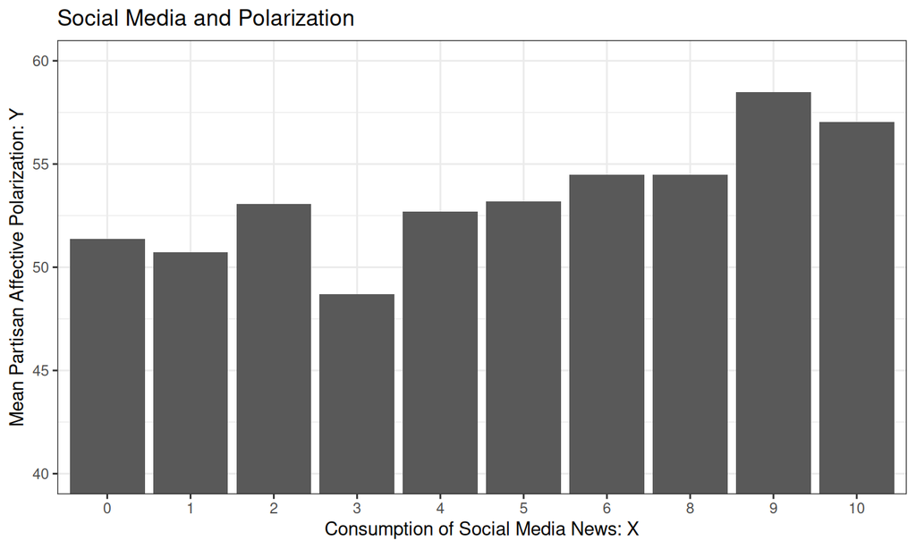

Correlation: 0.07, \(p \le\) 0.0000020

Does social media used **cause** polarization?

## Conclusion

\(1.\) Correlation as “solution” to Fundamental Problem of Causal Inference

\(2.\) Correlation suffers from two problems:

- Random Association: assess \(p\) values and statistical significance, based on assumptions about chance process
- Bias: we call this “confounding”, more on Thursday